# Survival Analysis Example

C. Savonen for ALSF CCDL

2019

**Purpose:**

An example for running basic survival analysis models which can be applied to various other data.

## Usage

This notebook is a template model that you can follow for all survival analyses. This includes using a wrapper function (`survival_analysis`) that can test given independent variables in the survival model and return back a table.

**Example use**

```
survival_analysis(metadata,
                  ind_var = <INDEPENDENT_VARIABLE(S)>,
                  test = <TEST_ABBR>,
                  ind_data = <DATA_FRAME>,
                  metadata_sample_col = "Kids_First_Biospecimen_ID",
                  ind_data_sample_col = <COLUMN THAT MATCHES METADATA's Kids_First_Biospecimen_ID>)
```

#### Options explanation:

- `metadata` : A data.frame that contains columns `OS_status` and `OS_days` to use for the survival model. This also assumes `LIVING` and `DECEASED` are the two statuses. This will be converted to a numeric variable for use with `survival` R functions. Samples with `NA`s are dropped.
- `ind_var`: A character string noting the name of the independent variable to test as a predictor for survival.
- `test` : A character string noting which test to use. Options: `"kap.meier"`, `"log.rank"`, or `"cox.reg"` (See below).
- `ind_data`: If the data for the independent variable needed for the test is not in `metadata`, add it here. This assumes it will be a data.frame with either a `Tumor_Sample_Barcode`, `Kids_First_Biospecimen_ID`, or `sample` column which to `dplyr::inner_join` with `metadata` by.
- `ind_data_sample_col` : A character string that states the name of the column in `ind_data` that contains the sample IDs that match to the metadata.
- `metadata_sample_col` : A character string that states the name of the column in `metadata` that contains the sample IDs that match to the ind_data.
- `os_days_col` : A character string that states the name of the column in `metadata` that contains the overall survival days information. Default is `OS_days`.
- `os_status_col` : A character string that states the name of the column in `metadata` that contains the overall survival status information The data in this column will be converted to numeric where `LIVING` = 1 and `DECEASED` = 2. (This is what `survminer` functions look for.) Default is `OS_status`.

#### `test` options:

- “kap.meier” : For basic survival analysis.
- “log.rank” : For use with categorical variables.
- “cox.reg” : For use with continuous variables.

#### Output:

A **list** with:  
1) The original `$model` fit object.  
2) The tidied results `$table`.  
3) The `$original_data` that was used in the model.

## Setup

#### Packages and functions

Read in set up script.

```r
# This script contains a wrapper function that can conduct the survival analyses
source(file.path("util", "survival_models.R"))

# Magrittr pipe
`%>%` <- dplyr::`%>%`
```

#### Set up files and directories

Set up output directories.

```r
data_dir <- file.path("..", "..", "data")
results_dir <- file.path("results", "template")
plots_dir <- "plots"
```

Make output directories.

```r
if (!dir.exists(results_dir)) {
  dir.create(results_dir)
}
if (!dir.exists(plots_dir)) {
  dir.create(plots_dir)
}
```

Declare input file paths.

```r
metadata_file <- file.path(data_dir, "pbta-histologies.tsv")
tmb_file <- file.path(data_dir, "pbta-snv-consensus-mutation-tmb-coding.tsv")
```

Declare output file paths.

```r
kap_meier_plot_file <- file.path(plots_dir, "survival_curve_gender.pdf")
logrank_table_file <- file.path(results_dir, "logrank_gender.tsv")
cox_table_file <- file.path(results_dir, "cox_regression_tmb.tsv")
```

## Import the metadata

```r
metadata <- readr::read_tsv(metadata_file, guess_max = 10000)
```

## Kaplan-Meier Example

The [Kaplan-Meier](https://www.ncbi.nlm.nih.gov/pmc/articles/PMC3059453/) survival curve shows the probability of survival over time.

```r
kap_fit <- survival_analysis(metadata,
  ind_var = "germline_sex_estimate",
  test = "kap.meier",
  metadata_sample_col = "Kids_First_Biospecimen_ID",
  ind_data_sample_col = "sample"
)
```

```
Testing model: survival::Surv(OS_days, OS_status) ~ germline_sex_estimate with kap.meier
```

`survminer` package comes with a convenient plotting function which uses `ggplot2` arguments. It requires the original Kaplain-Meier `survfit` object, so we will extract that with `$model`.

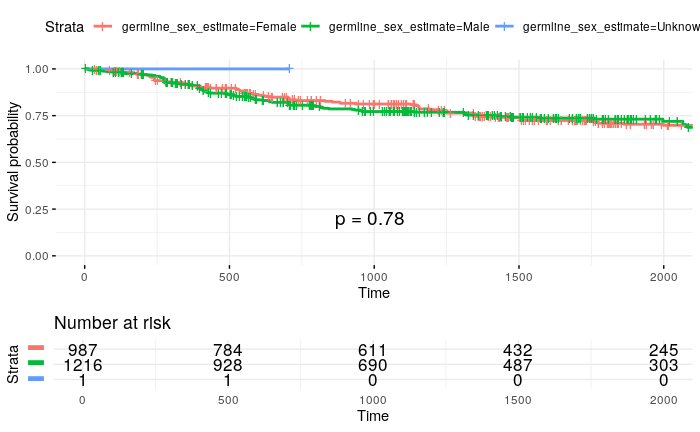

```r
surv_plot <- survminer::ggsurvplot(kap_fit$model,
  pval = TRUE,
  data = kap_fit$original_data,
  risk.table = TRUE,
  xlim = c(0, 2000),
  break.time.by = 500,
  ggtheme = theme_minimal(),
  risk.table.y.text.col = TRUE,
  risk.table.y.text = FALSE
)

# Make this plot a combined plot
surv_plot <- cowplot::plot_grid(surv_plot[[1]], surv_plot[[2]], nrow = 2,
                                rel_heights = c(2.5, 1))

# Print it out here
surv_plot
```

Save the plot to a file.

```r
# We can save the plot like a normal ggplot
cowplot::save_plot(filename = kap_meier_plot_file, plot = surv_plot)
```

## Log-Rank Example

For testing whether two survival curves are different, we can use Log-Rank which can be implemented using `survival::survdiff` function. In this example, we will test for survival curve differences between for `germline_sex_estimate` categories. Use the `survdiff` function to test the differences between the `Male` and `Female` curves.

```r
logrank_fit <- survival_analysis(metadata,
  ind_var = "germline_sex_estimate",
  test = "log.rank",
  metadata_sample_col = "Kids_First_Biospecimen_ID",
  ind_data_sample_col = "sample"
)
```

```
Testing model: survival::Surv(OS_days, OS_status) ~ germline_sex_estimate with log.rank
```

Print table of the results.

```r
# Print out the table here
logrank_fit$table %>%
  dplyr::mutate(p.value = logrank_fit$model$p.value) %>%
  knitr::kable(digits = 2)
```

[output not shown]

```r
# Save the table data in a TSV
readr::write_tsv(logrank_fit$table, logrank_table_file)
```

## Cox Regression Example

Cox Regression is a model suited for survival analysis where your independent variables are continuous. For this example, we’ll use Tumor Mutation Burden as our continuous variable.

```r
# Read in the data
tmb <- readr::read_tsv(tmb_file)
```

Plug this into a Cox Regression model using the function `survival::coxph`.

```r
cox_fit <- survival_analysis(metadata,
  ind_var = "tmb",
  test = "cox.reg",
  ind_data = tmb,
  metadata_sample_col = "Kids_First_Biospecimen_ID",
  ind_data_sample_col = "Tumor_Sample_Barcode"
)
```

```
Testing model: survival::Surv(OS_days, OS_status) ~ tmb with cox.reg
```

Take the output from this and make a table.

```r
# Print out the table here
cox_fit$table %>%
  knitr::kable(digits = 3)
```

| term | estimate | std.error | statistic | p.value | conf.low | conf.high |
| --- | --- | --- | --- | --- | --- | --- |
| tmb | 0.005 | 0.002 | 2.481 | 0.013 | 0.001 | 0.009 |

```r
# Save the table data in a TSV
readr::write_tsv(cox_fit$table, cox_table_file)
```